# Short-Term COVID-19 Projections

William Marble

March 11, 2020

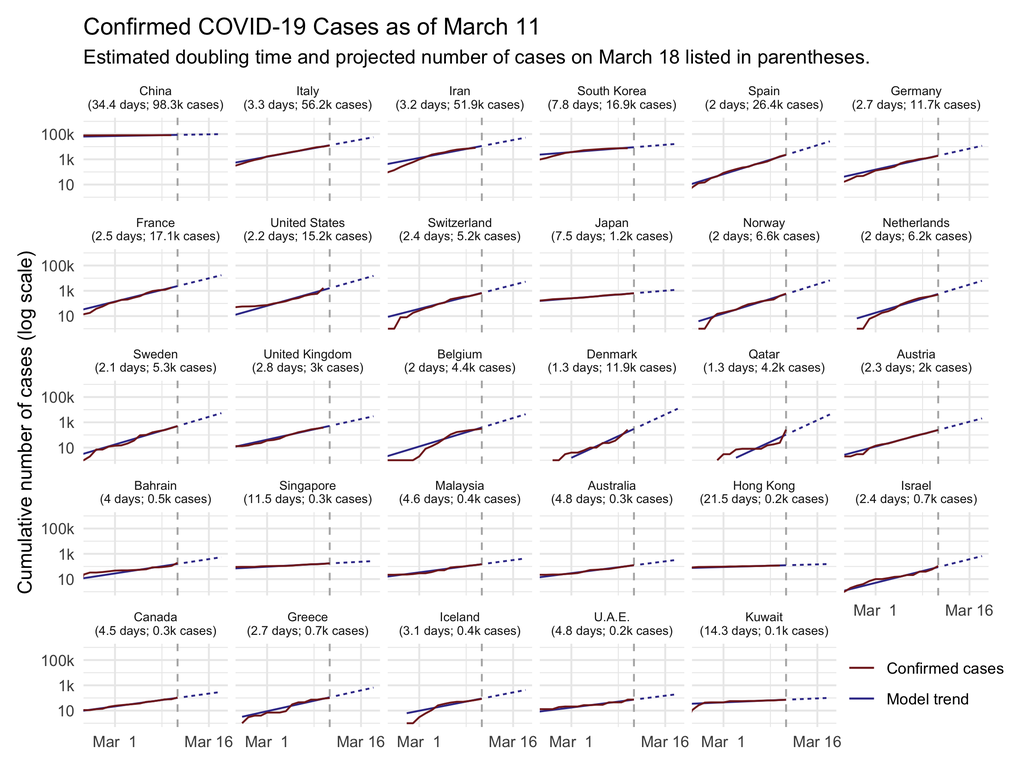

How many cases of COVID-19 should we expect across the world in the short term? While I’ve seen news articles reference various projections, I haven’t seen any models that update in real time. So I decided to produce one myself, to get a sense of what to expect over the next week or so.

The result is shown in the above figure. It displays the cumulative number of cases in red along with the estimated model used to make forecasts in blue. The solid blue line shows how well the model predicts past data, while the dotted blue line shows projections over the next 7 days. Note that the vertical axis is on the logarithmic scale.

The country labels also list the estimated doubling time — i.e., the number of days it takes for the number of cases doubles — and the projected number of cases on March 18 (a week from this writing). Across all countries, the average doubling time is 3.5 days, though it varies significantly by country.

The forecast suggests that there will be rapid spread of COVID-19 in the next week. If the recent trend continues, the model projects that in 7 days, there will be over 15,000 cases in the United States. The number of cases in the U.S. will double roughly roughly every 2 to 3 days. Large scale public health interventions — such as social distancing — are aimed at reducing the growth rate.

The current doubling time is similar in other countries that are struggling to contain COVID-19 — including Italy, Iran, Germany, and Spain. Meanwhile, the model estimates that several countries whose outbreaks started sooner have significantly slowed the spread. In China — the epicenter of the pandemic — the estimated doubling time is about 34 days. In South Korea, where there has been a large-scale response, the estimate is about 8 days.

| Country | Estimated Doubling Time | # Cases, March 11 | Projected # Cases, March 18 |
| --- | --- | --- | --- |
| China | 34.4 days | 80,757 | 98,268 |
| Italy | 3.3 days | 12,462 | 56,172 |
| Iran | 3.2 days | 8,042 | 51,937 |
| South Korea | 7.8 days | 7,513 | 16,856 |
| Spain | 2 days | 2,277 | 26,364 |
| Germany | 2.7 days | 1,908 | 11,674 |
| France | 2.5 days | 1,784 | 17,142 |
| United States | 2.2 days | 1,670 | 15,210 |
| Switzerland | 2.4 days | 652 | 5,243 |
| Japan | 7.5 days | 639 | 1,227 |
| Norway | 2 days | 598 | 6,638 |
| Netherlands | 2 days | 503 | 6,190 |
| Sweden | 2.1 days | 500 | 5,333 |
| United Kingdom | 2.8 days | 382 | 3,015 |
| Belgium | 2 days | 314 | 4,374 |
| Denmark | 1.3 days | 262 | 11,897 |
| Qatar | 1.3 days | 262 | 4,214 |
| Austria | 2.3 days | 246 | 2,038 |
| Bahrain | 4 days | 195 | 539 |
| Singapore | 11.5 days | 178 | 267 |
| Malaysia | 4.6 days | 149 | 433 |
| Australia | 4.8 days | 128 | 340 |
| Hong Kong | 21.5 days | 120 | 156 |
| Israel | 2.4 days | 109 | 662 |
| Canada | 4.5 days | 108 | 303 |
| Greece | 2.7 days | 99 | 662 |
| Iceland | 3.1 days | 85 | 431 |
| U.A.E. | 4.8 days | 74 | 201 |
| Kuwait | 14.3 days | 72 | 102 |
| Iraq | 5.4 days | 71 | 191 |
| India | 3.5 days | 62 | 270 |
| San Marino | 2.8 days | 62 | 374 |
| Lebanon | 3.2 days | 61 | 252 |
| Egypt | 1.9 days | 60 | 984 |
| Finland | 2.6 days | 59 | 355 |
| Thailand | 17.7 days | 59 | 75 |
| Philippines | 2 days | 49 | 483 |
| Taiwan | 27.2 days | 47 | 58 |
| Romania | 2.2 days | 45 | 325 |
| Ireland | 2.3 days | 43 | 381 |
| Czech Republic | 2.6 days | 41 | 358 |
| Brazil | 2.3 days | 38 | 336 |
| Viet Nam | 7.2 days | 31 | 67 |
| Georgia | 2.5 days | 24 | 162 |
| Algeria | 4.8 days | 20 | 65 |
| Russia | 3.1 days | 20 | 127 |
| Croatia | 6.5 days | 19 | 36 |
| Pakistan | 3.3 days | 19 | 71 |
| Oman | 10 days | 18 | 31 |
| Ecuador | 8.8 days | 17 | 30 |
| Estonia | 3.1 days | 16 | 79 |
| Azerbaijan | 5.3 days | 11 | 29 |
| Macao SAR | 120.9 days | 10 | 11 |

The rest of this blog post describes the methods used to produce these estimates.

### Methodology

I’ll now describe the methodology to arrive at the projections above. I use data on the number of confirmed cases in each country, curated by [Johns Hopkins CSSE](https://github.com/CSSEGISandData). Each observation lists the number of confirmed cases for a given country on a given date. I model the data using a simple exponential growth model, where the growth rate is allowed to vary by country. In estimating the model parameters, I up-weight more recent observations, by an amount that is tuned to provide good short-term (7-day-ahead) forecasts. I estimate the model via weighted maximum likelihood using the `R` package `lme4`.

#### The Basic Model

Formally, let $N_i(t)$ denote the number of cases in country $i$ at time $t$, where $t$ measures the number of days since the first reported cases. I estimate an exponential growth model of the form $N_i(t) = N_i(0) \exp(\beta t)$, which can equivalently be written
$$\log N_i(t) = \alpha_i + \beta t,$$
where $\alpha_i \equiv \log N_i(0)$.

A feature of the exponential growth model is that the doubling time is constant. We can easily derive it by finding $k$ such that $N(t+k)/N(t) = 2$. With a little algebra, this yields $k = \log(2)/\beta$. We can simply plug in our estimated $\hat{\beta}$ to get a doubling time estimate $\hat{k}$.

The growth rate $\beta$ is likely to vary slightly across countries, depending on the country’s public health response, the country’s population density, and so on. At the same time, the growth rate in one country is informative about what the growth rate in other countries will be. Therefore, I estimate a random-slopes version of the model above that allows for “partial pooling” across countries. More specifically, I allow $\beta$ to be indexed by country $i$, and model $\beta_i$ as being drawn from a normal distribution with mean $\mu_\beta$ and variance $\sigma^2_\beta$ (which are estimated from the data). Because the initial number of cases $N_i(0)$ may vary by country (depending, for example, on when tests were first administered), I also allow $\alpha_i$ to vary by country.

#### Optimizing the Estimates for Short-Term Projections

My goal is to generate reasonable projections for the number of confirmed cases we are likely to experience in the short term. Due to changing containment measures and other factors, the value of $\beta_i$ may change over time. More recent data points are therefore more informative for forecasting than data points further in the past. To account for this feature, I weight the observations $k$ days ago by a factor of $\delta^k$, with $\delta \in [0, 1]$. For example, data from today get weight $1$, data points from yesterday get weight $\delta$, data points from two days ago get weight $\delta^2$, and so on.

How should we pick $\delta$? I treat this as a parameter that we can tune by seeing how different values of $\delta$ would have performed in the past. I simulate how each potential $\delta$ would have performed if we were estimating the current number of cases using data up to a week ago. So, since I’m updating this notebook on March 11, I’ll make projections for the number of cumulative cases reported in each country today only using training data that would have been available on March 4, then compare the prediction to what actually happened.

Formally, denote the predictions generated using a given $\delta$ by $\hat{y}_i(\delta)$ and the values that actually occurred by $y_i$. (I should note that even though the model is estimated in log-linear form, in this section $y_i$ is in levels, not logs.) Because the scale of the data across countries varies so widely, I normalize the error by the true value, so the error is expressed as a percent of the truth. The error statistic is thus $\epsilon_i(\delta) \equiv 100 \times (\hat{y}_i(\delta) - y_i)/y_i$. I compute both root mean squared prediction error (RMSPE) and mean absolute prediction error (MAPE) for the hold out sample $i = 1, \dots, n$:
$$\begin{aligned}
\text{RMSPE}(\delta) &= \sqrt{\frac{1}{n} \sum_{i=1}^N (\epsilon_i(\delta))^2} \\
\text{MAPE}(\delta) &= \sqrt{\frac{1}{n} \sum_{i=1}^N \left| \epsilon_i(\delta) \right|} \\
\end{aligned}$$

I re-estimate the model for various choices of $\delta$, then compute the error statistics for each choice. I then choose $\delta^{opt}$ that produces projections with the lowest error. The error as a function of $\delta$ is shown in the next figure. Thankfully, the hold-out statistics (RMSPE and MAPE) generate nearly identical choices for $\delta^{opt}$, namely 0.66 and 0.67, respectively. With $\delta^{opt}$ in hand, I then re-fit the model using the full data set, and then make 7-days-ahead projections for each country.

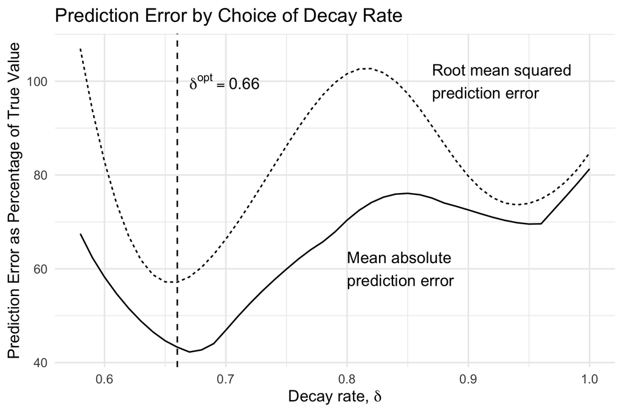

Interestingly, the optimal decay rate is relatively small, meaning that data points become less informative very quickly. A value of $\delta^{opt} = 0.66$ implies that data from 11 days ago is about 1% as data from today. (One potential reason for this is that the growth curve is very erratic when the total number of cases is low. An extension might allow $\delta^{opt}$ to vary by country, according to the number of days since the first reported case.)

#### Heterogeneity in Growth Rates

Finally, we can look at the estimated growth rates $\hat{\beta}_i$ for each country. The last figure shows the $\hat{\beta}_i$ estimates, with countries arranged in increasing number of total cases. There is not an obvious correlation between the number of confirmed cases and the current growth rate, except that countries with very few reported cases generally have a lower growth rate.

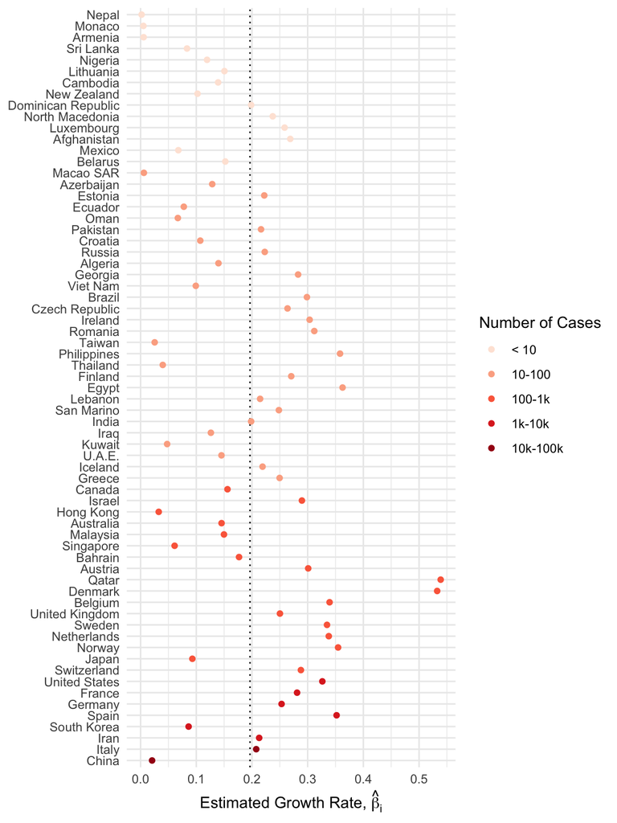

#### Further Caveats

This exercise uses the number of *confirmed cases*. As testing criteria loosen, more people are being tested and thus the number of detected cases as a proportion of all cases is increasing. This would suggest the estimates here are likely to *underestimate* the actual number of cases in the population. On the other hand, since testing has ramped up in recent weeks, it may be that the growth in confirmed cases is outpacing the growth in total cases. Since recent data is weighted more heavily, this effect would tend to overstate the growth rate — potentially generating an *overestimate*. Without more data, it’s hard to adjudicate which source of bias is likely to be more important.

Additionally, the large public health interventions that we’re beginning to see in the U.S. — social distancing, especially — are aimed at reducing the growth rate of COVID-19. As a result, the growth rate should decline in the coming weeks.